# Data Engineering & EDA

## Data Engineering

The full and complete data enginering path can be found in the scripts folder. For a quick summary you can look at the repository readme.

Here, we are going to go walk through the whole process, and then look at extracts and samples to do our analysis.

Let's first dicuss our data. All data was collected from: https://www.adsbexchange.com/products/historical-data/ . There is a lot of data offerend on this website. Samples are listed back to 2016. To get a good sample size for my project I downloaded one full day of data. We'll get into the analysis of how much data that ended up being a few lines down. I specifcally chose August 1, 2024. Here is why:

- relatively recent data
- it's a Thursday (mid-week)
- it's not near any major global holidays
- August typically has stable weather patterns globally
- most of Europe is on vacation, but their flights are replaced by leisure travelers, keeping volume similar
- it's outside of major conference/convention seasons
- schools aren't typically starting yet in most regions
- business travel is relatively normal in most regions

Documentation for the field values can be found here: https://www.adsbexchange.com/version-2-api-wip/

I am not going to extensively explain the field defintions here, as the documentation does a thorough and specific job. I will discuss information about the fields, their type, and their quality in various places throughout my analysis where it is pertinent to feature selection and engineering.

The scraping and storing of the data was done within _04_traces to_db.py . Here is brief summary of the operations:

- Processes aircraft trace data from ADS-B Exchange, downloading JSON files organized by hex values and dates
- Uses asynchronous operations and parallel processing with configurable batch and chunk sizes
- Pipeline includes validating hex ranges, fetching directory listings, downloading files, and deduplicating records
- Schema captures various aircraft parameters like position, speed, altitude, and technical details

The only data transformation done at this step was the use of the timestamp and the seen field to create a real point timestamp for every row, which is stored at actual_timestamp.

The table that stores the data is crated via sql/instantiate_aircraft_traces.sql; you can go there for a complete list of fields and data types.

## Tools used

Before looking at the results, I wanted to briefly discussed the main tools I used for the extraction and analysis, and why there were chosen:

- Async & Parallelization Tools:
  - aiohttp:
    - Manages concurrent HTTP downloads through connection pooling and memory-efficient streaming operations
    - Handles thousands of simultaneous connections while preventing memory overflow through backpressure mechanisms
    - Integrates natively with Python's async/await syntax for consistent error handling
  - asyncio:
    - Coordinates concurrent operations through an event loop architecture
    - Provides structured concurrency with task groups and cancellation handling
    - Enables non-blocking I/O operations while maintaining single-threaded execution model
  - concurrent.futures + multiprocessing:
    - Distributes CPU-intensive tasks across cores through process pools
    - Separates I/O-bound (ThreadPoolExecutor) from CPU-bound (ProcessPoolExecutor) operations
    - Manages process lifecycle and inter-process communication automatically
- Database & Analysis Tools:
  - PostgreSQL:
    - Handles high-volume concurrent writes while maintaining ACID compliance
    - Provides spatial indexing and geometric data types for flight path analysis
    - Enables complex querying through window functions and Common Table Expressions
- psycopg2:
  - Implements efficient bulk insert operations through execute_values
  - Manages connection pooling and transaction handling
  - Provides native support for PostgreSQL-specific data types and operations
- DuckDB:
  - Performs analytical queries through vectorized execution and columnar storage
  - Connects directly to PostgreSQL data without ETL overhead
  - Optimizes memory usage through chunk-wise processing and compression
- Support Tools:
- BeautifulSoup:
  - Parses HTML structures with consistent DOM traversal methods
  - Handles malformed HTML through lenient parsing algorithms
  - Extracts targeted data through CSS selectors and tree navigation

#### Import dependacnies and config

And now that we've talked about libraries, let's go ahead and import them, and do rest of out intial config.

```python
# install dependancies
import cartopy.crs as ccrs
import cartopy.feature as cfeature
import json
import matplotlib.pyplot as plt
from matplotlib.colors import LinearSegmentedColormap, Normalize
import numpy as np
import pandas as pd
import seaborn as sns

# define constants for field types, to be used for prints and visualization below
DECIMAL_COLUMNS: set = {
    'latitude', 'longitude', 'ground_speed', 'track',
    'roll_angle', 'nav_qnh', 'nav_heading', 'seconds_offset'
}

INTEGER_COLUMNS: set = {
    'altitude_baro', 'flags', 'vertical_rate_baro',
    'altitude_geom', 'vertical_rate_geom',
    'indicated_airspeed', 'nav_altitude_mcp',
    'nic', 'rc', 'version', 'nic_baro',
    'nac_p', 'nac_v', 'sil', 'gva', 'sda',
    'base_timestamp'
}

STRING_COLUMNS: set = {
    'icao', 'source_type', 'source_file_path',
    'flight', 'squawk', 'category', 'emergency',
    'sil_type'
}

TIMESTAMP_COLUMNS: set = {
    'actual_timestamp'
}

NUMERIC_COLUMNS: set = INTEGER_COLUMNS | DECIMAL_COLUMNS
```

## Exploratory Data Analysis

Once the data was loaded into the database, I performed an exploratory data analysis via scripts/05_traces_EDA.py . Querying the databse to get the results needed for the analysis, takes a while, so we're not going to do that here, but we are going to talk about it. Instead we're going to look at the extract of the analysis from scripts/05_traces_EDA.py and look at some sample data. First let's get set up out of the way.

And now let's start looking at some data!

```python
with open('../data/_05_traces_EDA/results.json') as f:
   results = json.load(f)

print(f'total rows: {results["total_rows"]}')
```

```
total rows: 106012947
```

And now we have some insight into why the queries take so long. The nubmer of trace points contain for a single day is almost 110M! Originally when I read in 1 whole day of daya using readhist-db the total point count was around 4 million. I had assumed it would be roughly the same for the traces data set. Nope. More than 20X bigger. Even at 4M rows a containerize PostgreSQL instance raeally hanldes everything pretty much fine, but at ~110M, it really starts to bog down. This create some fun challanges where I really had to optimize what I was doing for the rest of the pipeline to operate. But, we're going to be glad we imported all this data, but I'll get to that quite a bit later.

Now let's confirm that the data within all of those rows is going to give us sufficicient granularity:

```python
print(f'mean point count: {results["mean_point_count"]}')
print(f'mean duration: {results["mean_duration"]}')
```

```
mean point count: 1436.9765774313792
mean duration: {'value': 591.3681333333334, 'units': 'minutes'}
```

And we can see here that within that data set were are going to get many many high quality trace files of sufficient resolution and length to perform our analysis.

### Data Quality

The next thing I always want to know when approaching are: nulls, distinct, and distribution. With these 3 things I can really get start to get a feel for that data and determine what fields I do and do not want to use, so let's dig in.

#### Nulls

```python
# Create the DataFrame
df = pd.DataFrame([(k, v['null_count'], v['null_percentage']) for k, v in results['null_counts'].items()],
                 columns=['column', 'null_count', 'null_percentage']).sort_values('null_percentage', ascending=False)

# Create styled table with conditional formatting
styled_df = (df
 .style
 .background_gradient(subset=['null_percentage'], cmap='RdYlGn_r')  # Red to Yellow to Green (reversed)
 .bar(subset=['null_count'], color='#4a90e2', align='mid')  # Add bar charts
 .format({'null_count': '{:,.0f}', 'null_percentage': '{:.2f}%'})  # Format numbers
 .set_caption('Null Value Analysis')
)

# Display the styled table
display(styled_df)
```

Null Value Analysis

|  | column | null_count | null_percentage |
| --- | --- | --- | --- |
| 22 | nav_heading | 96,602,135 | 91.12% |
| 21 | nav_altitude_mcp | 89,994,428 | 84.89% |
| 20 | nav_qnh | 89,675,478 | 84.59% |
| 32 | gva | 85,316,951 | 80.48% |
| 27 | nic_baro | 84,900,087 | 80.08% |
| 23 | emergency | 83,323,742 | 78.60% |
| 33 | sda | 82,688,535 | 78.00% |
| 28 | nac_p | 81,176,967 | 76.57% |
| 30 | sil | 81,176,967 | 76.57% |
| 29 | nac_v | 81,142,798 | 76.54% |
| 26 | version | 81,072,294 | 76.47% |
| 18 | squawk | 80,804,778 | 76.22% |
| 31 | sil_type | 80,607,579 | 76.04% |
| 17 | flight | 80,527,271 | 75.96% |
| 19 | category | 80,342,197 | 75.79% |
| 25 | rc | 79,474,668 | 74.97% |
| 24 | nic | 79,474,668 | 74.97% |
| 14 | roll_angle | 77,374,927 | 72.99% |
| 13 | indicated_airspeed | 76,158,240 | 71.84% |
| 12 | vertical_rate_geom | 52,363,303 | 49.39% |
| 11 | altitude_geom | 16,265,169 | 15.34% |
| 10 | vertical_rate_baro | 12,659,719 | 11.94% |
| 8 | track | 5,740,441 | 5.41% |
| 7 | ground_speed | 928,291 | 0.88% |
| 6 | altitude_baro | 169,471 | 0.16% |
| 0 | icao | 0 | 0.00% |
| 1 | actual_timestamp | 0 | 0.00% |
| 16 | source_file_path | 0 | 0.00% |
| 3 | seconds_offset | 0 | 0.00% |
| 15 | source_type | 0 | 0.00% |
| 5 | longitude | 0 | 0.00% |
| 4 | latitude | 0 | 0.00% |
| 9 | flags | 0 | 0.00% |
| 2 | base_timestamp | 0 | 0.00% |

#### Distinct Values

```python
# Create the DataFrame for distinct counts and sort by distinct_count
df_distinct = pd.DataFrame([(k, v['distinct_count'], v['distinct_percentage']) for k, v in results['distinct_counts'].items()],
                         columns=['column', 'distinct_count', 'distinct_percentage']).sort_values('distinct_count', ascending=False)

# Create styled table with conditional formatting
styled_df_distinct = (df_distinct
 .style
 .background_gradient(subset=['distinct_percentage'], cmap='RdYlGn')  # Green to Yellow to Red
 .bar(subset=['distinct_count'], color='#4a90e2', align='mid')  # Blue bars
 .format({'distinct_count': '{:,.0f}', 'distinct_percentage': '{:.2f}%'})  # Format numbers
 .set_caption('Distinct Value Analysis (Sorted by Distinct Count)')
)

# Display the styled table
display(styled_df_distinct)
```

Distinct Value Analysis (Sorted by Distinct Count)

|  | column | distinct_count | distinct_percentage |
| --- | --- | --- | --- |
| 5 | longitude | 27,078,173 | 25.54% |
| 4 | latitude | 7,946,936 | 7.50% |
| 3 | seconds_offset | 7,477,602 | 7.05% |
| 1 | actual_timestamp | 7,477,602 | 7.05% |
| 17 | flight | 141,395 | 0.13% |
| 0 | icao | 73,775 | 0.07% |
| 16 | source_file_path | 73,775 | 0.07% |
| 7 | ground_speed | 10,504 | 0.01% |
| 18 | squawk | 4,092 | 0.00% |
| 10 | vertical_rate_baro | 3,863 | 0.00% |
| 8 | track | 3,601 | 0.00% |
| 11 | altitude_geom | 3,260 | 0.00% |
| 6 | altitude_baro | 3,100 | 0.00% |
| 21 | nav_altitude_mcp | 1,957 | 0.00% |
| 12 | vertical_rate_geom | 1,199 | 0.00% |
| 22 | nav_heading | 880 | 0.00% |
| 13 | indicated_airspeed | 753 | 0.00% |
| 20 | nav_qnh | 599 | 0.00% |
| 14 | roll_angle | 241 | 0.00% |
| 19 | category | 30 | 0.00% |
| 9 | flags | 16 | 0.00% |
| 25 | rc | 15 | 0.00% |
| 28 | nac_p | 15 | 0.00% |
| 24 | nic | 12 | 0.00% |
| 23 | emergency | 8 | 0.00% |
| 26 | version | 8 | 0.00% |
| 29 | nac_v | 8 | 0.00% |
| 15 | source_type | 7 | 0.00% |
| 33 | sda | 4 | 0.00% |
| 30 | sil | 4 | 0.00% |
| 32 | gva | 4 | 0.00% |
| 31 | sil_type | 3 | 0.00% |
| 27 | nic_baro | 2 | 0.00% |
| 2 | base_timestamp | 1 | 0.00% |

```python
# create high and low cardinality constants for use below

LOW_CARDINALITY_COLUMNS = {k for k, v in results['distinct_counts'].items() if v['distinct_count'] <= 32}
HIGH_CARDINALITY_COLUMNS = {k for k, v in results['distinct_counts'].items() if v['distinct_count'] > 32}

print("Low cardinality:", LOW_CARDINALITY_COLUMNS)
print("High cardinality:", HIGH_CARDINALITY_COLUMNS)
```

[output not shown]

```python
distinct_values = results['distinct_values']
max_length = max(len(values) if isinstance(values, list) else 1 for values in distinct_values.values())
disinct_df = pd.DataFrame(
    {
        k: sorted([x for x in (v if isinstance(v, list) else [v]) if x is not None and x != ""]) +
        [x for x in (v if isinstance(v, list) else [v]) if x is None or x == ""] +
        [""] * (max_length - len(v if isinstance(v, list) else [v]))
        for k, v in distinct_values.items()
    }
).sort_index(axis=1)

# Create and display the transformed DataFrame
display(disinct_df)
```

|  | base_timestamp | category | emergency | flags | gva | nac_p | nac_v | nic | nic_baro | rc | sda | sil | sil_type | source_type | version |
| --- | --- | --- | --- | --- | --- | --- | --- | --- | --- | --- | --- | --- | --- | --- | --- |
| 0 | 1722470400 | A0 | downed | 0 | 0 | 0 | 0 | 0 | 0 | 0 | 0 | 0 | perhour | adsb_icao | 0 |
| 1 |  | A1 | general | 1 | 1 | 1 | 1 | 1 | 1 | 8 | 1 | 1 | persample | adsb_icao_nt | 1 |
| 2 |  | A2 | lifeguard | 2 | 2 | 2 | 2 | 2 | None | 25 | 2 | 2 | unknown | adsc | 2 |
| 3 |  | A3 | minfuel | 3 | 3 | 3 | 3 | 3 |  | 75 | 3 | 3 | None | adsr_icao | 3 |
| 4 |  | A4 | none | 4 | None | 4 | 4 | 4 |  | 186 | None | None |  | mlat | 4 |
| 5 |  | A5 | nordo | 5 |  | 5 | 5 | 5 |  | 371 |  |  |  | other | 5 |
| 6 |  | A6 | reserved | 6 |  | 6 | 6 | 6 |  | 556 |  |  |  | tisb_icao | 6 |
| 7 |  | A7 | unlawful | 7 |  | 7 | 7 | 7 |  | 926 |  |  |  |  | 7 |
| 8 |  | B0 | None | 8 |  | 8 | None | 8 |  | 1112 |  |  |  |  | None |
| 9 |  | B1 |  | 9 |  | 9 |  | 9 |  | 1852 |  |  |  |  |  |
| 10 |  | B2 |  | 10 |  | 10 |  | 10 |  | 3704 |  |  |  |  |  |
| 11 |  | B3 |  | 11 |  | 11 |  | 11 |  | 7408 |  |  |  |  |  |
| 12 |  | B4 |  | 12 |  | 12 |  | None |  | 14816 |  |  |  |  |  |
| 13 |  | B5 |  | 13 |  | 13 |  |  |  | 18520 |  |  |  |  |  |
| 14 |  | B6 |  | 14 |  | 14 |  |  |  | 37040 |  |  |  |  |  |
| 15 |  | B7 |  | 15 |  | None |  |  |  | None |  |  |  |  |  |
| 16 |  | C0 |  |  |  |  |  |  |  |  |  |  |  |  |  |
| 17 |  | C1 |  |  |  |  |  |  |  |  |  |  |  |  |  |
| 18 |  | C2 |  |  |  |  |  |  |  |  |  |  |  |  |  |
| 19 |  | C3 |  |  |  |  |  |  |  |  |  |  |  |  |  |
| 20 |  | C4 |  |  |  |  |  |  |  |  |  |  |  |  |  |
| 21 |  | C6 |  |  |  |  |  |  |  |  |  |  |  |  |  |
| 22 |  | C7 |  |  |  |  |  |  |  |  |  |  |  |  |  |
| 23 |  | D0 |  |  |  |  |  |  |  |  |  |  |  |  |  |
| 24 |  | D1 |  |  |  |  |  |  |  |  |  |  |  |  |  |
| 25 |  | D2 |  |  |  |  |  |  |  |  |  |  |  |  |  |
| 26 |  | D4 |  |  |  |  |  |  |  |  |  |  |  |  |  |
| 27 |  | D5 |  |  |  |  |  |  |  |  |  |  |  |  |  |
| 28 |  | D6 |  |  |  |  |  |  |  |  |  |  |  |  |  |
| 29 |  | D7 |  |  |  |  |  |  |  |  |  |  |  |  |  |
| 30 |  | None |  |  |  |  |  |  |  |  |  |  |  |  |  |

### Distributions

Now I want to look at the ditributions of within the data. To do this we're going to be using my one of my favs, the violin plot! Because the dataset is so big, we're going to be use a randomly sampled subset of the data. We're loading in a saved sample of the data that contains a 0.5% sample of the whole dataset, which is still 500K+ rows.

```python
# read in sample data
df = pd.read_parquet('../data/_05_traces_EDA/traces_sample.parquet')

print("rows in sample data:", len(df))

display(df.head())
```

```
rows in sample data: 530361
```

|  | icao | actual_timestamp | base_timestamp | seconds_offset | latitude | longitude | altitude_baro | ground_speed | track | flags | ... | nic | rc | version | nic_baro | nac_p | nac_v | sil | sil_type | gva | sda |
| --- | --- | --- | --- | --- | --- | --- | --- | --- | --- | --- | --- | --- | --- | --- | --- | --- | --- | --- | --- | --- | --- |
| 0 | a88037 | 2024-08-01 14:20:47.290000+00:00 | 1722470400 | 51647.29 | 40.935943 | -112.167788 | 4900.0 | 124.5 | 168.40 | 0 | ... | NaN | NaN | NaN | NaN | NaN | NaN | NaN | None | NaN | NaN |
| 1 | a88037 | 2024-08-01 14:29:59.140000+00:00 | 1722470400 | 52199.14 | 40.852707 | -112.049133 | 4300.0 | 106.9 | 243.90 | 0 | ... | NaN | NaN | NaN | NaN | NaN | NaN | NaN | None | NaN | NaN |
| 2 | a4bb00 | 2024-08-01 22:37:13.790000+00:00 | 1722470400 | 81433.79 | 30.748963 | -89.342139 | 3300.0 | 105.2 | 86.70 | 4 | ... | NaN | NaN | NaN | NaN | NaN | NaN | NaN | None | NaN | NaN |
| 3 | a88037 | 2024-08-01 14:43:10.520000+00:00 | 1722470400 | 52990.52 | 40.873796 | -112.043131 | 4100.0 | 129.2 | 33.30 | 0 | ... | NaN | NaN | NaN | NaN | NaN | NaN | NaN | None | NaN | NaN |
| 4 | a88037 | 2024-08-01 16:44:44.800000+00:00 | 1722470400 | 60284.80 | 41.164169 | -112.175842 | 4100.0 | 119.6 | 237.60 | 0 | ... | 0.0 | 186.0 | NaN | 0.0 | 9.0 | 1.0 | 3.0 | perhour | 2.0 | 2.0 |

5 rows × 34 columns

### Time field analysis

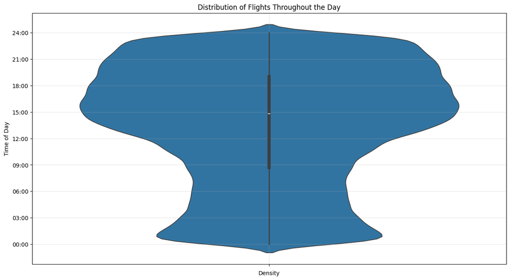

```python
df['minutes_since_midnight'] = df['actual_timestamp'].dt.hour * 60 + df['actual_timestamp'].dt.minute

# Create the violin plot
plt.figure(figsize=(15, 8))
sns.violinplot(y='minutes_since_midnight', data=df)

# Customize the y-axis to show hours for better readability
hours = range(0, 25, 3)  # Create ticks every 3 hours
plt.yticks(ticks=[h*60 for h in hours],
          labels=[f'{h:02d}:00' for h in hours])

plt.title('Distribution of Flights Throughout the Day')
plt.ylabel('Time of Day')
plt.xlabel('Density')

# Add grid for better readability
plt.grid(True, alpha=0.3)

plt.show()
```

## Geospatial Field Analysis

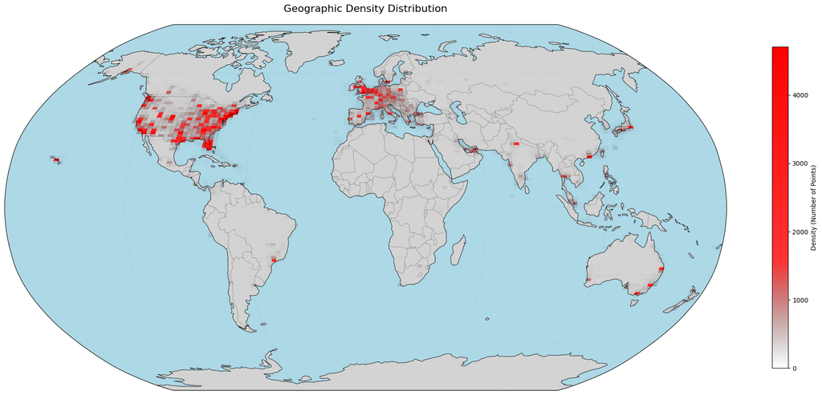

```python
# plot geo density plot of lat/lon fields

plt.figure(figsize=(20, 12))
ax = plt.axes(projection=ccrs.Robinson())

ax.add_feature(cfeature.LAND, facecolor='lightgray', edgecolor='black', linewidth=0.5)
ax.add_feature(cfeature.OCEAN, facecolor='lightblue')
ax.add_feature(cfeature.COASTLINE, linewidth=0.5)
ax.add_feature(cfeature.BORDERS, linestyle=':', linewidth=0.5)

lon = df['longitude'].astype(float)
lat = df['latitude'].astype(float)

hist, xedges, yedges = np.histogram2d(
    lon, lat,
    bins=150,
    range=[[-180, 180], [-90, 90]]
)

colors = [
    (0,0,0,0),
    (1,0,0,0.8),
    (1,0,0,0.9),
    (1,0,0,1)
]
custom_cmap = LinearSegmentedColormap.from_list('custom', colors)

# You can control the thresholds explicitly using vmin and vmax
mesh = plt.pcolormesh(xedges, yedges, hist.T,
               transform=ccrs.PlateCarree(),
               cmap=custom_cmap,
               shading='auto',
               norm=Normalize(vmin=0, vmax=hist.max()/2)  # Adjust this fraction to control intensity
)

ax.gridlines(linewidth=0.2, color='gray', alpha=0.5, linestyle='--')
ax.set_global()
plt.colorbar(mesh, label='Density (Number of Points)', shrink=0.6)
plt.title('Geographic Density Distribution', pad=20, size=16)
plt.tight_layout()
plt.show()
```

I want to note here that it looks like we have essentially no data over the sea. We are not going to count for the incompleteness of the data over the ocean explicitly, but we will account for implicitly by filtering out incomplete or low point desnity flight traces.

### Numeric field distributions

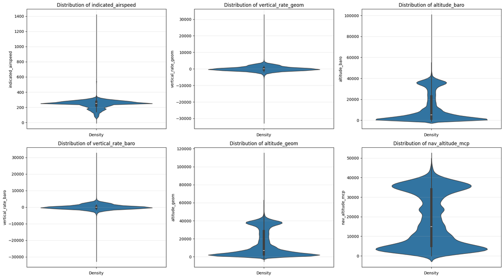

```python
# Get columns that are both integer and high cardinality
plot_columns = list(HIGH_CARDINALITY_COLUMNS & INTEGER_COLUMNS)

# Calculate number of columns and rows for the subplot grid
n_cols = 3
n_rows = (len(plot_columns) + n_cols - 1) // n_cols

# Create subplots
plt.figure(figsize=(6*n_cols, 5*n_rows))

for i, column in enumerate(plot_columns, 1):
    plt.subplot(n_rows, n_cols, i)

    # Create the violin plot
    sns.violinplot(y=column, data=df)

    plt.title(f'Distribution of {column}')
    plt.ylabel(column)
    plt.xlabel('Density')

    # Add grid for better readability
    plt.grid(True, alpha=0.3)

# Adjust layout to prevent overlap
plt.tight_layout()
plt.show()
```

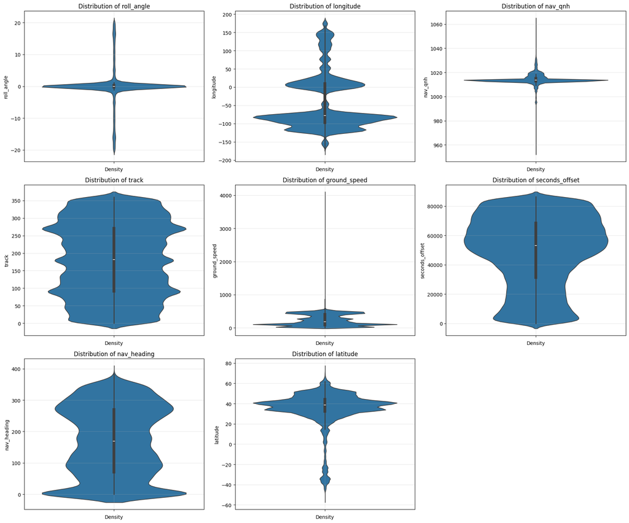

```python
# Get columns that are float and high cardinality
plot_columns = list(HIGH_CARDINALITY_COLUMNS & DECIMAL_COLUMNS)

# Calculate number of columns and rows for the subplot grid
n_cols = 3
n_rows = (len(plot_columns) + n_cols - 1) // n_cols

# Create subplots
plt.figure(figsize=(6*n_cols, 5*n_rows))

for i, column in enumerate(plot_columns, 1):
    plt.subplot(n_rows, n_cols, i)

    # Create the violin plot
    sns.violinplot(y=column, data=df)

    plt.title(f'Distribution of {column}')
    plt.ylabel(column)
    plt.xlabel('Density')

    # Add grid for better readability
    plt.grid(True, alpha=0.3)

# Adjust layout to prevent overlap
plt.tight_layout()
plt.show()
```

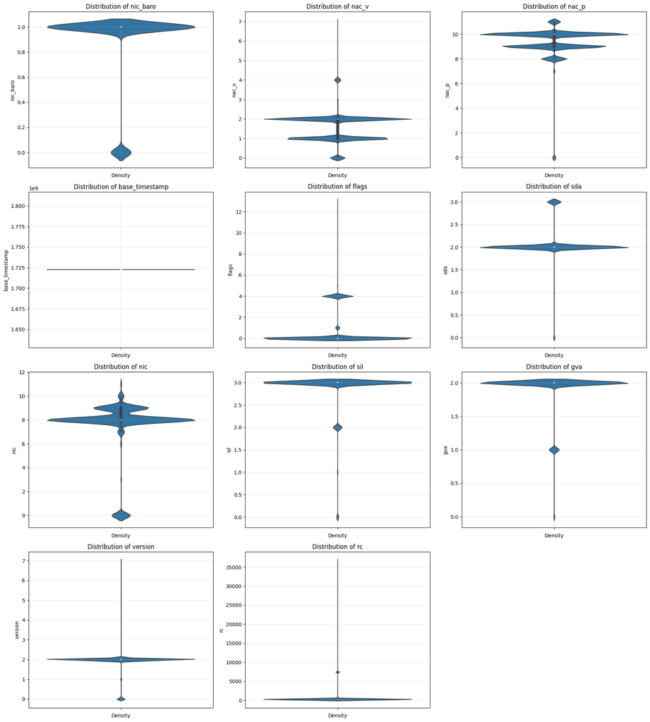

```python
# Get columns that are float and high cardinality
plot_columns = list(LOW_CARDINALITY_COLUMNS & NUMERIC_COLUMNS)

# Calculate number of columns and rows for the subplot grid
n_cols = 3
n_rows = (len(plot_columns) + n_cols - 1) // n_cols

# Create subplots
plt.figure(figsize=(6*n_cols, 5*n_rows))

for i, column in enumerate(plot_columns, 1):
    plt.subplot(n_rows, n_cols, i)

    # Create the violin plot
    sns.violinplot(y=column, data=df)

    plt.title(f'Distribution of {column}')
    plt.ylabel(column)
    plt.xlabel('Density')

    # Add grid for better readability
    plt.grid(True, alpha=0.3)

# Adjust layout to prevent overlap
plt.tight_layout()
plt.show()
```

### String & Categorical Field Analysis

```
{'emergency', 'category', 'source_type', 'sil_type', 'squawk'}
```

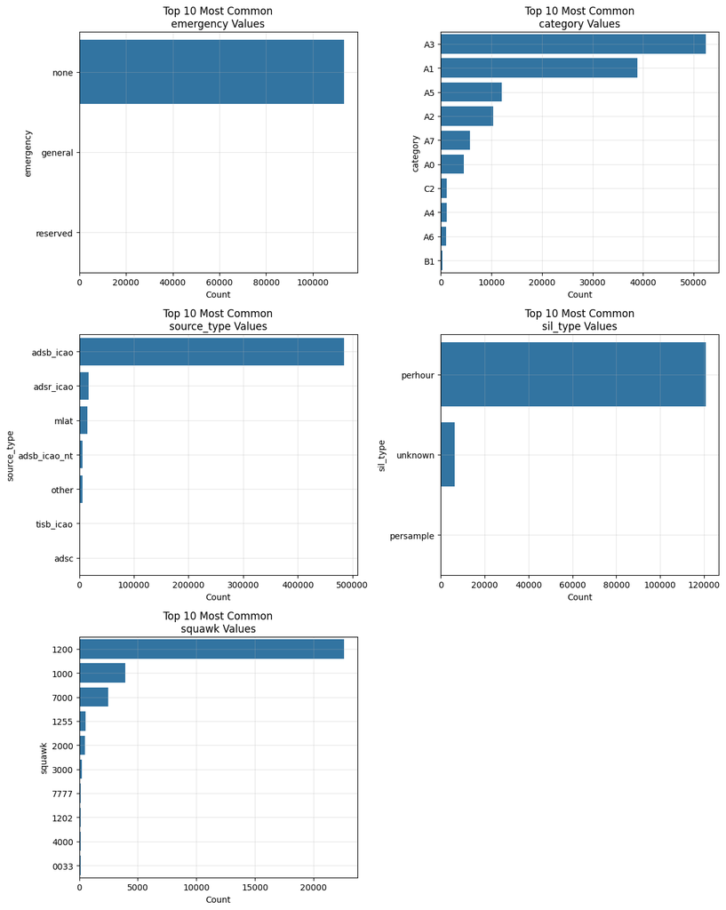

```python
# Get string/categorical columns
STRING_COLUMNS.difference_update({'icao', 'source_file_path', 'flight'})

print(STRING_COLUMNS)

# Calculate number of columns and rows for the subplot grid
n_cols = 2
n_rows = (len(STRING_COLUMNS) + n_cols - 1) // n_cols

plt.figure(figsize=(6*n_cols, 5*n_rows))

for i, column in enumerate(STRING_COLUMNS, 1):
    plt.subplot(n_rows, n_cols, i)

    # Get top 10 most frequent categories
    top_categories = df[column].value_counts().nlargest(10).index

    # Filter data to only include top categories
    plot_data = df[df[column].isin(top_categories)]

    # Create count plot
    sns.countplot(data=plot_data, y=column, order=plot_data[column].value_counts().index)

    plt.title(f'Top 10 Most Common\n{column} Values')
    plt.xlabel('Count')

    # Add grid for better readability
    plt.grid(True, alpha=0.3)

plt.tight_layout()
plt.show()
```

### Correlation matrix

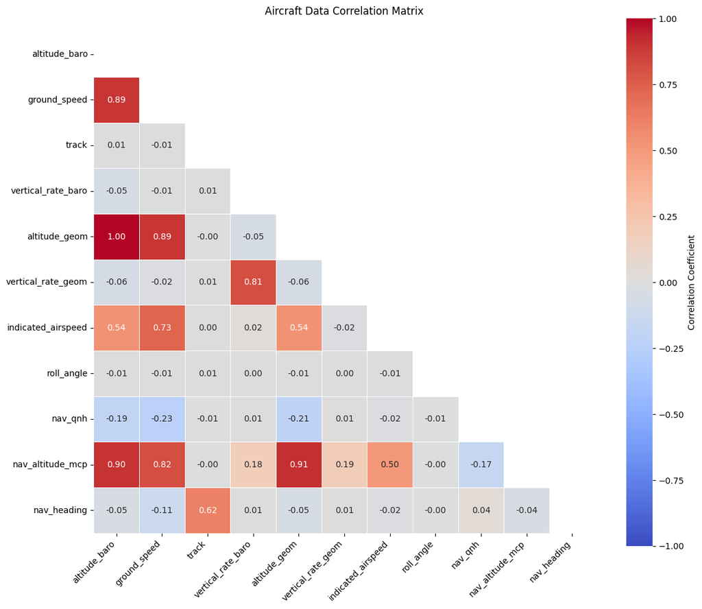

```python
# Assuming your dataframe is called 'df'
# Select numeric columns that make sense to correlate
correlatable_columns = [
    'altitude_baro', 'ground_speed', 'track',
    'vertical_rate_baro', 'altitude_geom',
    'vertical_rate_geom', 'indicated_airspeed',
    'roll_angle', 'nav_qnh', 'nav_altitude_mcp',
    'nav_heading'
]

# Create correlation matrix
corr_matrix = df[correlatable_columns].corr()

# Create a mask for the upper triangle
mask = np.triu(np.ones_like(corr_matrix, dtype=bool))

# Set up the matplotlib figure
plt.figure(figsize=(12, 10))

# Create heatmap
sns.heatmap(
    corr_matrix,
    mask=mask,
    annot=True,  # Show correlation values
    cmap='coolwarm',  # Color scheme
    vmin=-1, vmax=1,  # Value range
    center=0,  # Center the colormap at 0
    square=True,  # Make the plot square-shaped
    fmt='.2f',  # Round correlation values to 2 decimal places
    linewidths=0.5,  # Width of the lines between cells
    cbar_kws={'label': 'Correlation Coefficient'}
)

# Rotate x-axis labels for better readability
plt.xticks(rotation=45, ha='right')
plt.yticks(rotation=0)

# Adjust layout to prevent label cutoff
plt.tight_layout()

# Add title
plt.title('Aircraft Data Correlation Matrix', pad=20)

# Show the plot
plt.show()
```

## Field Selection

Now, after having comleted the EDA, here is what fields I intend to use, might use, and won't use for feature generation and other steps moving forward:

WILL USE

- Core Sensor Data
  - latitude
  - longitude
  - altitude_baro
  - ground_speed
  - track
  - vertical_rate_baro
  - indicated_airspeed
- Reference Only
  - icao
  - actual_timestamp
  - seconds_offset

MIGHT USE

- High Null Fields with Potential Value
  - nav_altitude_mcp
  - nav_heading
  - nav_qnh
  - roll_angle
- Potential Label/Event Fields
  - flags
  - emergency
  - squawk
  - flight
  - category

WON'T USE

- Metadata
  - source_type
  - source_file_path
  - base_timestamp
- Overcorrelated Redundant
  - altitude_geom
  - vertical_rate_geom
- Data Quality Indicators
  - nic
  - rc
  - version
  - nic_baro
  - nac_p
  - nac_v
  - sil
  - sil_type
  - gva
  - sda

#### Next up...

Proceed to the next notebook, where we take the fields we've selected and begin feature generation.